# Communicate/Automate

**Communicate/Automate**は[Data Science Workflow](https://github.com/rstudio/RStartHere) （[CC BY 4.0](https://creativecommons.org/licenses/by/4.0/deed.ja) ）にて定義されている分析結果の報告書の作成や公開の公開を行うプロセスです。

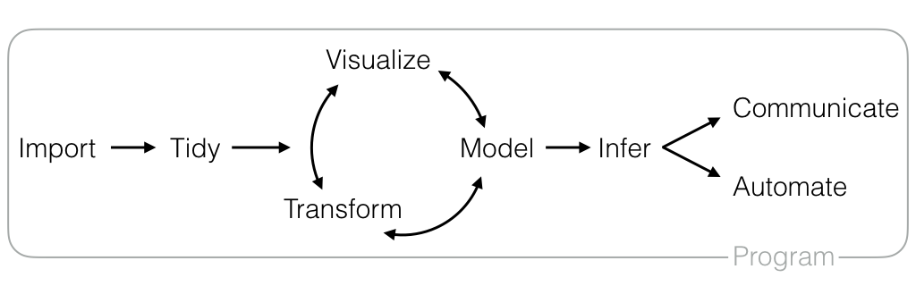

Data Science Workflow, RStudio Inc. CC BY 4.0

データ分析には一般的に

- データの透明性
- 分析の透明性

が求められます。更に最近では

- 分析の再現性（Reproducible Research）

も求められています。事業系であれば、それらに加えて

- 分析の生産性

も求められる訳です。しかしながら、分析結果の報告はデータの前処理と並んで手間のかかる仕事です。分析結果を成果としてまとめるためには、当然、分析過程ので記録が必要になります。つまり、常に分析と並行して記録を残す必要があります。ところが、分析に集中すると記録がおろそかになったり、記録に集中すると分析が中途半端になったりと間違いを誘発することは容易に想像ができます。  
[R](https://www.r-project.org/) ではこれらの問題を解決して生産性が高く、分析再現性が確保できるコミュニケーション・ツールが提供されています。

## Communicate

[R](https://www.r-project.org/) の最も有用なコミュニケーション・ツールである[R Markdown](http://rmarkdown.rstudio.com/) について取り上げます。

## Auctomate

分析結果をインタラクティブに表示できる[Shiny](https://shiny.rstudio.com/) や[flexdashboard](http://rmarkdown.rstudio.com/flexdashboard/index.html) について取り上げる予定です。

[CC BY-NC-SA 4.0](http://creativecommons.org/licenses/by-nc-sa/4.0/deed.ja) , Sampo Suzuki [2018-04-23 15:30(JST)]